# PPA Homework 3

Jia Yue, Ong

2024-10-18

# 1. Introduction:

Selection bias occurs when “individuals or groups in a study differ systematically from the population of interest leading to a systematic error in an association or outcome” (Nunan, et al., 2017). In the case of policing data, selection bias can arise from selective enforcement due to an “officer’s preconceived or biased beliefs” (Steif, 2021). For instance, patrolling neighborhood with perceived higher crime rates may lead to an under reporting of crimes in other neighborhood. Crime predictions based on such data will not be able to generalise across space.

I select pick-pocketing as my outcome that likely suffers from more selection bias than burglary. This is because the data only shows for cases where the pick pocket is caught. When a person finds out they have been pick pocketed, it is unlikely they knew exactly when and where the incident occurred. They could make a police report, but it is also possible victims choose to not report as they do not know if the item is recoverable. It is therefore possible that in areas with higher patrol, victims are more likely to seek the assistance of police in recovering their pick pocketed belongings due to the faster response time. Areas with higher police patrol may also mean that officers notice more incidents of pick pocketing in public spaces, leading to higher reporting of pickpocketing

# 2. Visualizing Pick pocket crime:

I plot the counts of pick pocket crime in point and fishnet to observe their distribution. Figure 1.1 and Figure 1.2 show the maps of pick pocket incidents in point and fishnet respectively. It is interesting to note that pick pocket appear clustered in Chicago’s downtown.

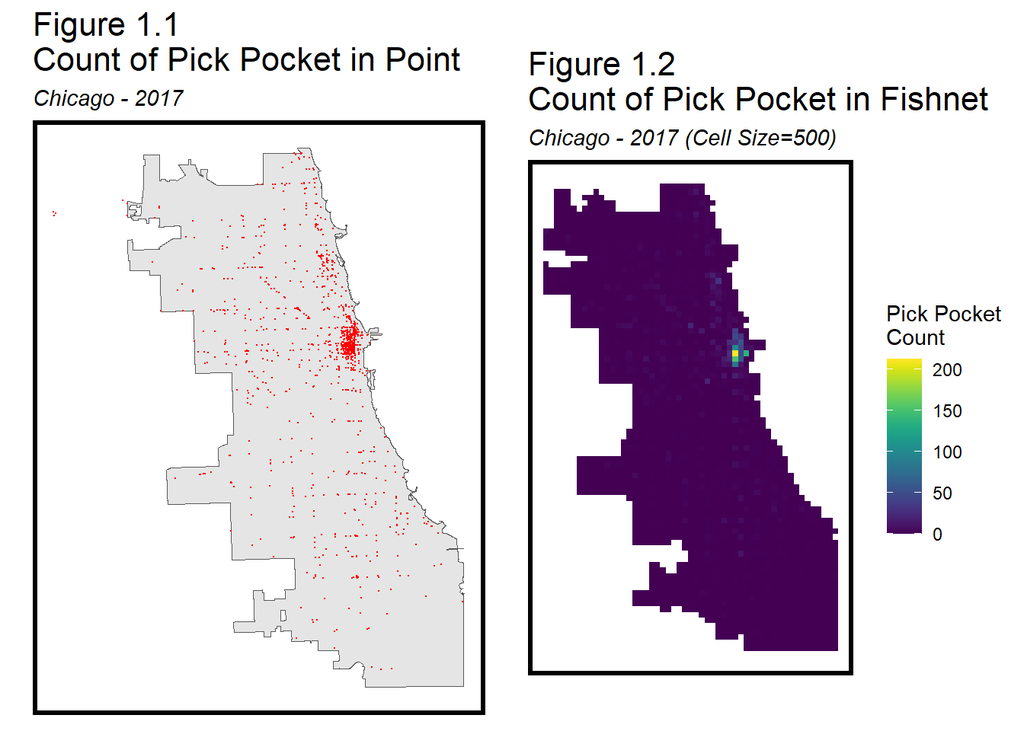

# 3. Risk factors

## 3.1 Count of risk factors by grid cell

I examine the count of each risk factors by grid cell through five small multiple maps. They follow different spatial process. Liquor and Entertainment venues, Rail Stations, Restaurants and Markets appear are mainly clustered in Chicago’s downtown. Bus Stop and Street Lights Out are more dispersed throughout Chicago.

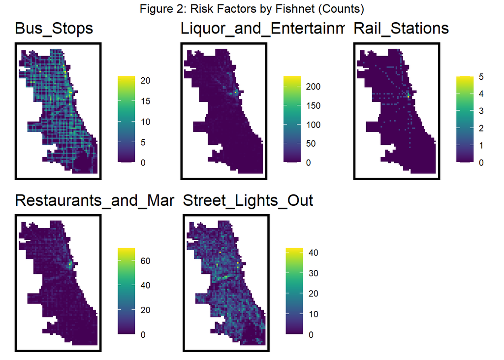

## 3.2 Correlation of pickpocket to risk factors

The correlation between count of pickpocket and each risk factors were plotted in Figure 3. This gives important context and provide us with intuition on risk factors that may predict count of pickpocket. There is a moderately strong correlation between pickpocket and liquor and entertainment, restaurants and markets.

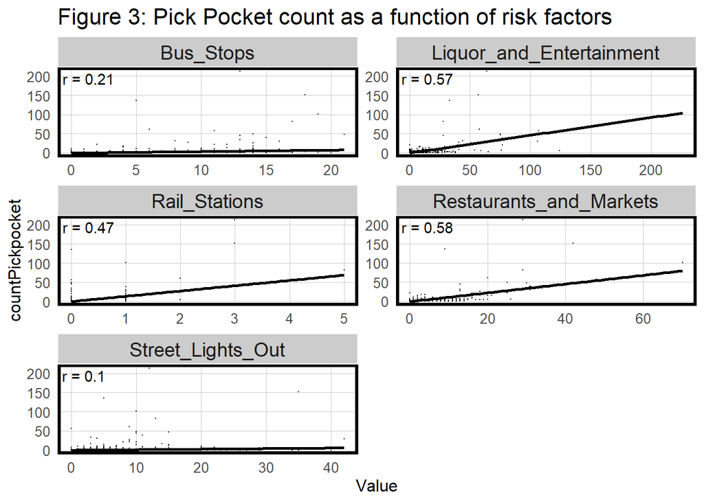

```r
final_net <-
  left_join(crime_net, st_drop_geometry(vars_net), by="uniqueID")

final_net <-
  st_centroid(final_net) %>%
    st_join(dplyr::select(neighborhoods, name)) %>%
    st_join(dplyr::select(policeDistricts, District)) %>%
      st_drop_geometry() %>%
      left_join(dplyr::select(final_net, geometry, uniqueID)) %>%
      st_sf() %>%
  na.omit()

#Correlation Scatterplots
correlation.long <-
  st_drop_geometry(final_net) %>%
    dplyr::select(-uniqueID, -cvID, -name, -District) %>%
    gather(Variable, Value, -countPickpocket)

correlation.cor <-
  correlation.long %>%
    group_by(Variable) %>%
    summarize(correlation = cor(Value, countPickpocket, use = "complete.obs"))

ggplot(correlation.long, aes(Value, countPickpocket)) +
  geom_point(size = 0.1) +
  geom_text(data = correlation.cor, aes(label = paste("r =", round(correlation, 2))),
            x=-Inf, y=Inf, vjust = 1.5, hjust = -.1) +
  geom_smooth(method = "lm", se = FALSE, colour = "black") +
  facet_wrap(~Variable, ncol = 2, scales = "free") +
  labs(title = "Figure 3: Pick Pocket count as a function of risk factors") +
  plotTheme()
```

# 4. Exploring the spatial process of pickpocket (Local Moran’s I)

Local Moran’s I is used to test for clustering at more local scales. The null hypothesis is that pickpocket count at a given location is randomly distributed relative to its immediate neighbors. Figure 4 below describes the local spatial process of pick pocket. The relatively high values of I represent strong and statistically significant evidence of local clustering at 5% level of significance. This is further supported by the p-value and significant hotspot maps. Additionally, we plot a map showing the distance to highly significant pick pocket hotspots in Chicago (Figure 5)

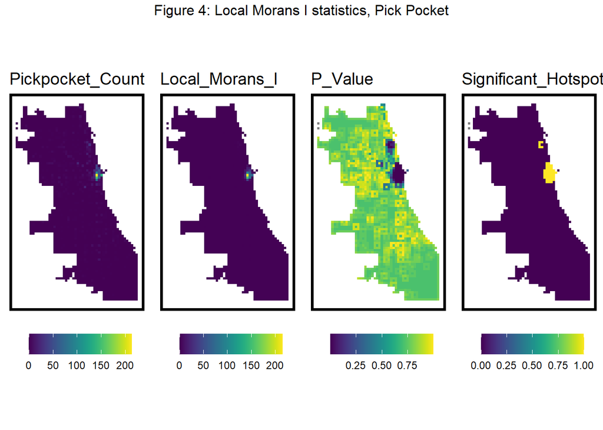

```r
final_net.nb <- poly2nb(as_Spatial(final_net), queen=TRUE)
final_net.weights <- nb2listw(final_net.nb, style="W", zero.policy=TRUE)
print(final_net.weights, zero.policy=TRUE)

local_morans <- localmoran(final_net$countPickpocket, final_net.weights, zero.policy=TRUE) %>%
  as.data.frame()

# Join local Moran's I results to fishnet
final_net.localMorans <-
  cbind(local_morans, as.data.frame(final_net)) %>%
  st_sf() %>%
  dplyr::select(Pickpocket_Count = countPickpocket,
                Local_Morans_I = Ii,
                P_Value = `Pr(z != E(Ii))`) %>%
  mutate(Significant_Hotspots = ifelse(P_Value <= 0.05, 1, 0)) %>%
  gather(Variable, Value, -geometry)

vars <- unique(final_net.localMorans$Variable)
varList <- list()

for(i in vars){
  varList[[i]] <-
    ggplot() +
      geom_sf(data = filter(final_net.localMorans, Variable == i),
              aes(fill = Value), colour=NA) +
      scale_fill_viridis(name="") +
      labs(title=i) +
      mapTheme(title_size = 14) + theme(legend.position="bottom")}

do.call(grid.arrange,c(varList, ncol = 4, top = "Figure 4: Local Morans I statistics, Pick Pocket"))
```

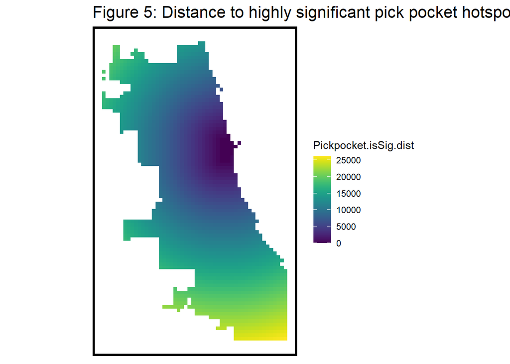

```r
final_net <-
  final_net %>%
  mutate(Pickpocket.isSig =
           ifelse(localmoran(final_net$countPickpocket,
                             final_net.weights)[,5] <= 0.0000001, 1, 0)) %>%
  mutate(Pickpocket.isSig.dist =
           nn_function(st_coordinates(st_centroid(final_net)),
                       st_coordinates(st_centroid(
                         filter(final_net, Pickpocket.isSig == 1))), k=1))

ggplot() +
      geom_sf(data = final_net, aes(fill=Pickpocket.isSig.dist), colour=NA) +
      scale_fill_viridis(name="Pickpocket.isSig.dist") +
      labs(title="Figure 5: Distance to highly significant pick pocket hotspots") +
      mapTheme()
```

# 5. Poisson Regression Model and random k-fold validation.

Figure 6 shows a skewed distribution of countPickpocket. A poisson regression is applied to the data and cross-validated using k-fold. k-fold cross-validation involves randomly dividing the whole dataset into k groups (folds) of approximately equal size. Each fold is used once as a validation set while the model is fitted on the remaining k-1 folds. The Mean Squared Error (MSE) is computed for each validation fold, and this process is repeated k times with a different fold used as the validation data set each time.

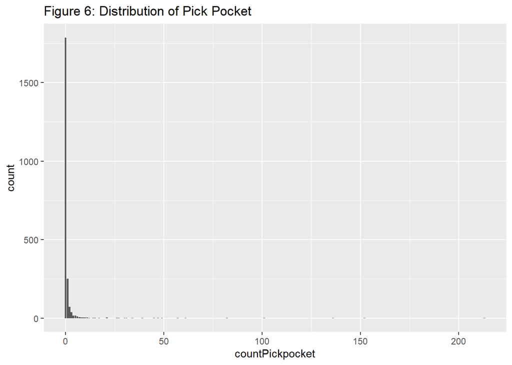

```r
#Visualise the distribution of pick pocket
ggplot(final_net,aes(x=countPickpocket))+
  geom_bar() +
    labs(title="Figure 6: Distribution of Pick Pocket")
```

```r
#Cross-validated Poisson Regression
reg.vars <- c("Liquor_and_Entertainment", "Restaurants_and_Markets",
              "Rail_Stations", "Bus_Stops")
reg.ss.vars <- c("Liquor_and_Entertainment", "Restaurants_and_Markets",
              "Rail_Stations", "Bus_Stops","Pickpocket.isSig","Pickpocket.isSig.dist")

reg.cv <- crossValidate(
  dataset = final_net,
  id = "cvID",
  dependentVariable = "countPickpocket",
  indVariables = reg.vars) %>%
    dplyr::select(cvID = cvID, countPickpocket, Prediction, geometry)

reg.ss.cv <- crossValidate(
  dataset = final_net,
  id = "cvID",
  dependentVariable = "countPickpocket",
  indVariables = reg.ss.vars) %>%
    dplyr::select(cvID = cvID, countPickpocket, Prediction, geometry)
```

# 6. Accuracy and Generalizability

## 6.1 A histogram of model errors.

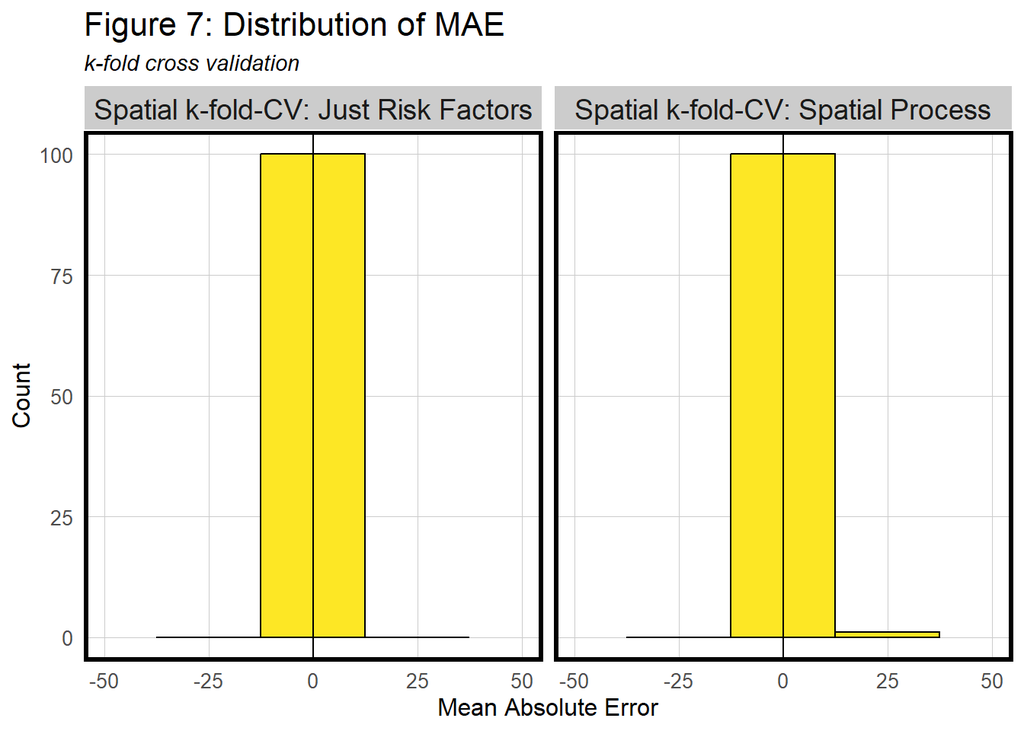

```r
reg.summary <-
  rbind(
    mutate(reg.cv,
           Error = Prediction - countPickpocket,
           Regression = "Spatial k-fold-CV: Just Risk Factors"),
    mutate(reg.ss.cv,
           Error = Prediction - countPickpocket,
           Regression = "Spatial k-fold-CV: Spatial Process")) %>%
    st_sf()

error_by_reg_and_fold <-
  reg.summary %>%
    group_by(Regression, cvID) %>%
    summarize(Mean_Error = mean(Prediction - countPickpocket, na.rm = T),
              MAE = mean(abs(Mean_Error), na.rm = T),
              SD_MAE = mean(abs(Mean_Error), na.rm = T)) %>%
  ungroup()

error_by_reg_and_fold %>%
  ggplot(aes(MAE)) +
    geom_histogram(bins = 5, colour="black", fill = "#FDE725FF") +
    facet_wrap(~Regression) +
    geom_vline(xintercept = 0) + scale_x_continuous(breaks = seq(-50, 50, by = 10)) +
    labs(title="Figure 7: Distribution of MAE", subtitle = "k-fold cross validation",
         x="Mean Absolute Error", y="Count") +
  xlim(-50,50)+
    plotTheme()
```

## 6.2 Table of model errors

```r
st_drop_geometry(error_by_reg_and_fold) %>%
  group_by(Regression) %>%
    summarize(Mean_MAE = mean(MAE),
              SD_MAE = sd(MAE)) %>%
  kable(caption = "Table 1: MAE and standard error by regression type") %>%
  kable_minimal()
```

[output not shown]

## 6.3 Map of model errors

Figure 8 visualizes the k-fold cross-validation errors spatially. These maps visualize where the higher errors occur when the local spatial process is not accounted for. The largest errors are dispersed throughout Chicago, with the hotspot location containing one cell that has high errors.

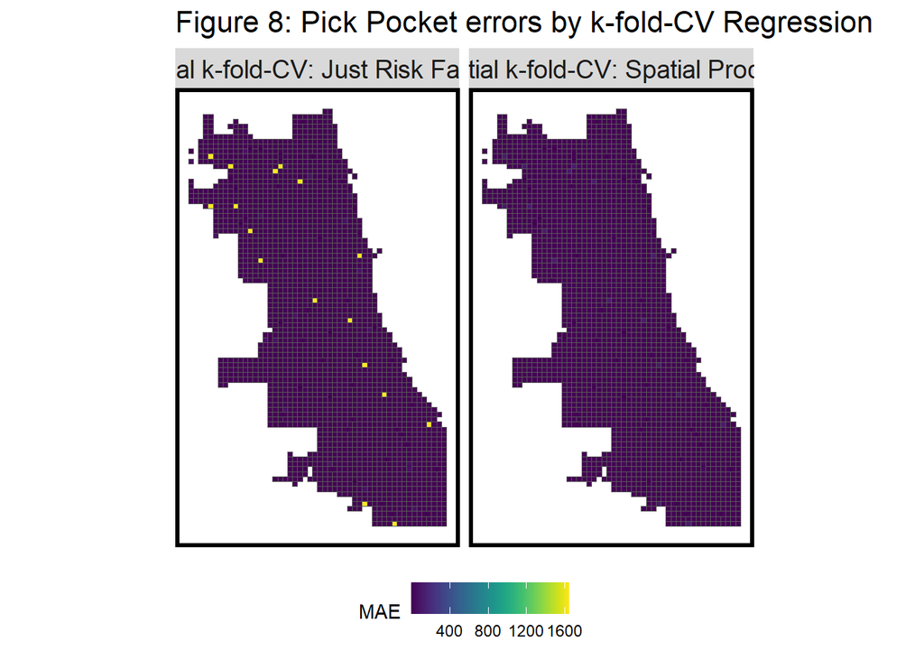

```r
error_by_reg_and_fold %>%
  filter(str_detect(Regression, "k-fold")) %>%
  ggplot() +
    geom_sf(aes(fill = MAE)) +
    facet_wrap(~Regression) +
    scale_fill_viridis() +
    labs(title = "Figure 8: Pick Pocket errors by k-fold-CV Regression") +
    mapTheme() + theme(legend.position="bottom")
```

## 6.4 Generalizability by neighborhood context

I explore whether the algorithm generalize across different neighborhood contexts. I used tidycensus to pull race and income data by census tract. percentWhite is calculated and tracts are split into two groups, Majority_White (more than 50%) and Majority_Non_White (less than 50%). Tracts are also split into two income groups, High_Income (>$58,000) and Low_Income (<$58,000). $58,000 is chosen as the threshold because Chicago defines low income as 80-percent or less of that $71,673 median income figure (Anon, n.d.; US Census Bureau, 2023).

```r
#Table of raw errors by neighborhood demographic
census_api_key("dea28a23f0b75d54e9eea0421b87003d3bd5c2d9", overwrite = TRUE)

tracts17 <-
  get_acs(geography = "tract", variables = c("B01001_001E","B01001A_001E","B06011_001"),
          year = 2017, state=17, county=031, geometry=T) %>%
  st_transform('ESRI:102271')  %>%
  dplyr::select(variable, estimate, GEOID) %>%
  spread(variable, estimate) %>%
  rename(TotalPop = B01001_001,
         NumberWhites = B01001A_001,
         Median_Income = B06011_001) %>%
  mutate(percentWhite = NumberWhites / TotalPop,
         raceContext = ifelse(percentWhite > .5, "Majority_White", "Majority_Non_White"),
         incomeContext = ifelse(Median_Income > 58000, "High_Income", "Low_Income")) %>%
  .[neighborhoods,]

# Table of raw errors by mean
reg.summary %>%
  filter(str_detect(Regression, "k-fold")) %>%
    st_centroid() %>%
    st_join(tracts17) %>%
    na.omit() %>%
      st_drop_geometry() %>%
      group_by(Regression, raceContext) %>%
      summarize(mean.Error = mean(Error, na.rm = T)) %>%
      spread(raceContext, mean.Error) %>%
      kable(caption = "Table 2: Mean Error by neighborhood racial context") %>%
        kable_styling("striped", full_width = F)


reg.summary %>%
  filter(str_detect(Regression, "k-fold")) %>%
    st_centroid() %>%
    st_join(tracts17) %>%
    na.omit() %>%
      st_drop_geometry() %>%
      group_by(Regression, incomeContext) %>%
      summarize(mean.Error = mean(Error, na.rm = T)) %>%
      spread(incomeContext, mean.Error) %>%
      kable(caption = "Table 3: Mean Error by neighborhood income context") %>%
        kable_styling("striped", full_width = F)
```

[output not shown]

# 7. Comparing kernel density to risk predictions for 2018’s crime.

I assess whether our risk predictions outperform traditional ‘Kernel density’ hotspot mapping. To add a temporal dimension to generalizability, hotspot and risk predictions from these 2017 pick pockets are used to predict the location of pick pockets from 2018.

For my analysis, I downloaded data of 2018 pickpocket from Chicago Open Data site. I then computed the Kernel Density on 2017 pick pockets, scaling the kernel density values to 1-100 and reclassifying the scaled values to 5 risk categories. I then spatial join the density and count of pickpockets in 2018 for each grid cell to the fishnet. The same process is repeated form risk predictions and the results are plotted in Figure 9 and 10.

Figure 9 shows the risk categories for both model types with a sample of Pickpocket18 points overlaid. A strongly fit model should show that the highest risk category is uniquely targeted to places with a high density of pickpocket points.

Figure 10 calculates the rate of 2018 pickpocket points by risk category and model type. A well fit model should show that the risk predictions capture a greater share of 2018 pickpocket in the highest risk category relative to the Kernel density. The risk prediction model is below the Kernel Density in the top two highest risk categories - suggesting this simple model has little value relative to the business-as-usual hot spot approach.

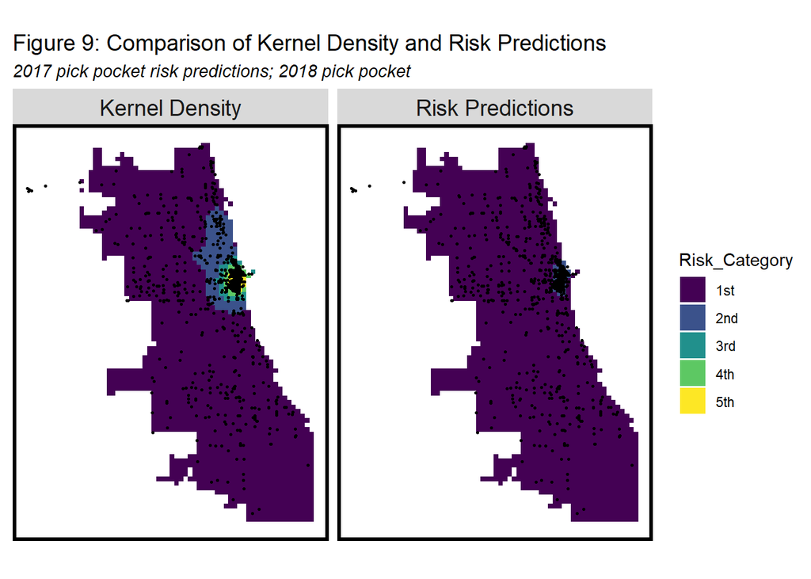

```r
Pickpocket18<-
  read.socrata("https://data.cityofchicago.org/Public-Safety/Crimes-2018/3i3m-jwuy") %>%
    filter(Primary.Type == "THEFT" & Description == "POCKET-PICKING") %>%
    mutate(x = gsub("[()]", "", Location)) %>%
    separate(x,into= c("Y","X"), sep=",") %>%
    mutate(X = as.numeric(X),Y = as.numeric(Y)) %>%
    na.omit() %>%
    st_as_sf(coords = c("X", "Y"), crs = 4326, agr = "constant")%>%
    st_transform('ESRI:102271') %>%
    distinct()

#Kernel Width
Pickpocket_ppp <- as.ppp(st_coordinates(Pickpocket17), W = st_bbox(final_net))
Pickpocket_KD.1000 <- spatstat.explore::density.ppp(Pickpocket_ppp, 1000)

#Incident
Pickpocket_KDE_sum <- as.data.frame(Pickpocket_KD.1000) %>%
  st_as_sf(coords = c("x", "y"), crs = st_crs(final_net)) %>%
  aggregate(., final_net, mean)


kde_breaks <- classIntervals(Pickpocket_KDE_sum$value,
                             n = 5, "fisher")


Pickpocket_KDE_sf <- Pickpocket_KDE_sum %>%
  mutate(label = "Kernel Density",
         Risk_Category = classInt::findCols(kde_breaks),
         Risk_Category = case_when(
           Risk_Category == 5 ~ "5th",
           Risk_Category == 4 ~ "4th",
           Risk_Category == 3 ~ "3rd",
           Risk_Category == 2 ~ "2nd",
           Risk_Category == 1 ~ "1st")) %>%
  cbind(
    aggregate(
      dplyr::select(Pickpocket18) %>% mutate(PickpocketCount = 1), ., sum) %>%
    mutate(PickpocketCount = replace_na(PickpocketCount, 0))) %>%
  dplyr::select(label, Risk_Category, PickpocketCount)

#Predictions
ml_breaks <- classIntervals(reg.ss.cv$Prediction,
                             n = 5, "fisher")
Pickpocket_risk_sf <-
  reg.ss.cv %>%
  mutate(label = "Risk Predictions",
         Risk_Category =classInt::findCols(ml_breaks),
         Risk_Category = case_when(
           Risk_Category == 5 ~ "5th",
           Risk_Category == 4 ~ "4th",
           Risk_Category == 3 ~ "3rd",
           Risk_Category == 2 ~ "2nd",
           Risk_Category == 1 ~ "1st")) %>%
  cbind(
    aggregate(
      dplyr::select(Pickpocket18) %>% mutate(PickpocketCount = 1), ., sum) %>%
      mutate(PickpocketCount = replace_na(PickpocketCount, 0))) %>%
  dplyr::select(label,Risk_Category, PickpocketCount)

#Map
rbind(Pickpocket_KDE_sf, Pickpocket_risk_sf) %>%
  na.omit() %>%
  gather(Variable, Value, -label, -Risk_Category, -geometry) %>%
  ggplot() +
    geom_sf(aes(fill = Risk_Category), colour = NA) +
    geom_sf(data = sample_n(Pickpocket18, 3000, replace = TRUE), size = .5, colour = "black") + #check reaplce = TRUE
    facet_wrap(~label, ) +
    scale_fill_viridis(discrete = TRUE) +
    labs(title="Figure 9: Comparison of Kernel Density and Risk Predictions",
         subtitle="2017 pick pocket risk predictions; 2018 pick pocket") +
    mapTheme(title_size = 14)
```

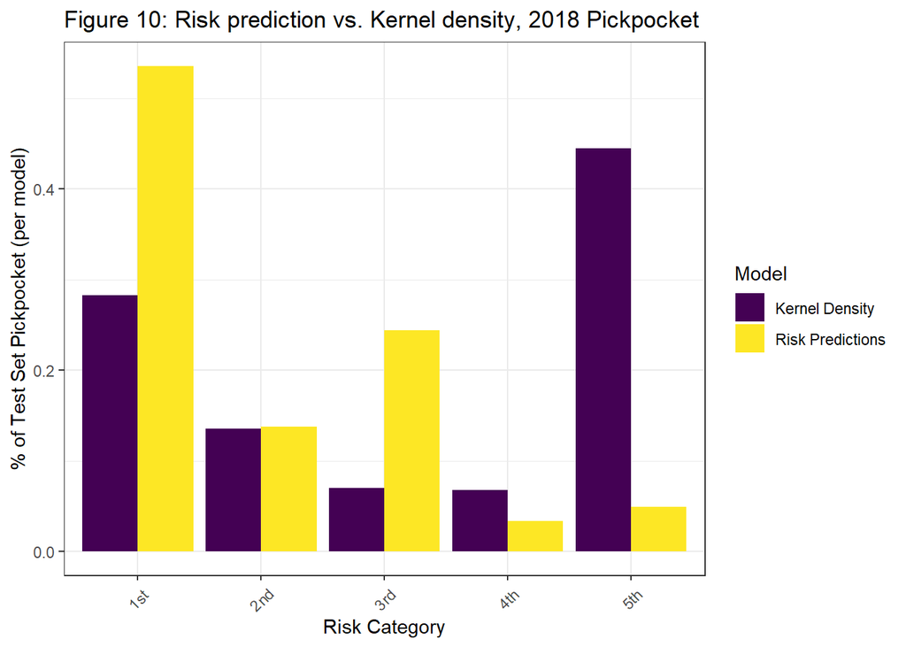

```r
#Bar Plot
rbind(Pickpocket_KDE_sf, Pickpocket_risk_sf) %>%
  st_drop_geometry() %>%
  na.omit() %>%
  gather(Variable, Value, -label, -Risk_Category) %>%
  group_by(label, Risk_Category) %>%
  summarize(countPickpocket = sum(Value)) %>%
  ungroup() %>%
  group_by(label) %>%
  mutate(Pcnt_of_test_set_crimes = countPickpocket / sum(countPickpocket)) %>%
    ggplot(aes(Risk_Category,Pcnt_of_test_set_crimes)) +
      geom_bar(aes(fill=label), position="dodge", stat="identity") +
      scale_fill_viridis(discrete = TRUE, name = "Model") +
      labs(title = "Figure 10: Risk prediction vs. Kernel density, 2018 Pickpocket",
           y = "% of Test Set Pickpocket (per model)",
           x = "Risk Category") +
  theme_bw() +
      theme(axis.text.x = element_text(angle = 45, vjust = 0.5))
```

# 8. Conclusion:

I would not recommend my algorithm to be put into use because it appear to have latent risk and poor fit. This is evident in Section 7 when my model was tested on predicting pick pocket crimes in 2018: the risk predictions were lower than kernel density. For my model to improve, further investigation is required into risk factors that are better predictors of pick pocketing.

Additionally, it is possible as mentioned in the introduction that victims did not report about their pickpocketing incidents. This could result in survivorship bias, where the data is limited only reported incidents of pickpocketing- it is possible that areas with higher reporting of pickpockets are well-patrolled to began with, leading to a higher number of reporting compared to areas with less policing footprint. Recommending my algorithm could lead to less resources allocated to patrolling areas with high pick pocketing but low reportings.

# References

1. Anon (n.d.) 5-15-020 Definitions. American Legal Publishing. https://codelibrary.amlegal.com/codes/chicago/latest/chicago_il/0-0-0-2639558 [Accessed: 18 October 2024].
2. Catalogue of Bias Collaboration, Nunan D, Bankhead C, Aronson JK. Selection bias. Catalogue Of Bias 2017: http://www.catalogofbias.org/biases/selection-bias/
3. Steif, K. (2021). Public Policy Analytics: Code and Context for Data Science in Government (1st ed.). CRC Press. https://doi.org/10.1201/9781003054658
4. US Census Bureau (2023) QuickFacts Chicago city, Illinois. 2023. https://www.census.gov/quickfacts/fact/table/chicagocityillinois/LND110210.